# InVivoStat Single Measure Parametric Analysis

## Response

The Resp 1 response is currently being analysed by the Single Measures Parametric Analysis module.

## Scatterplot of the observed data

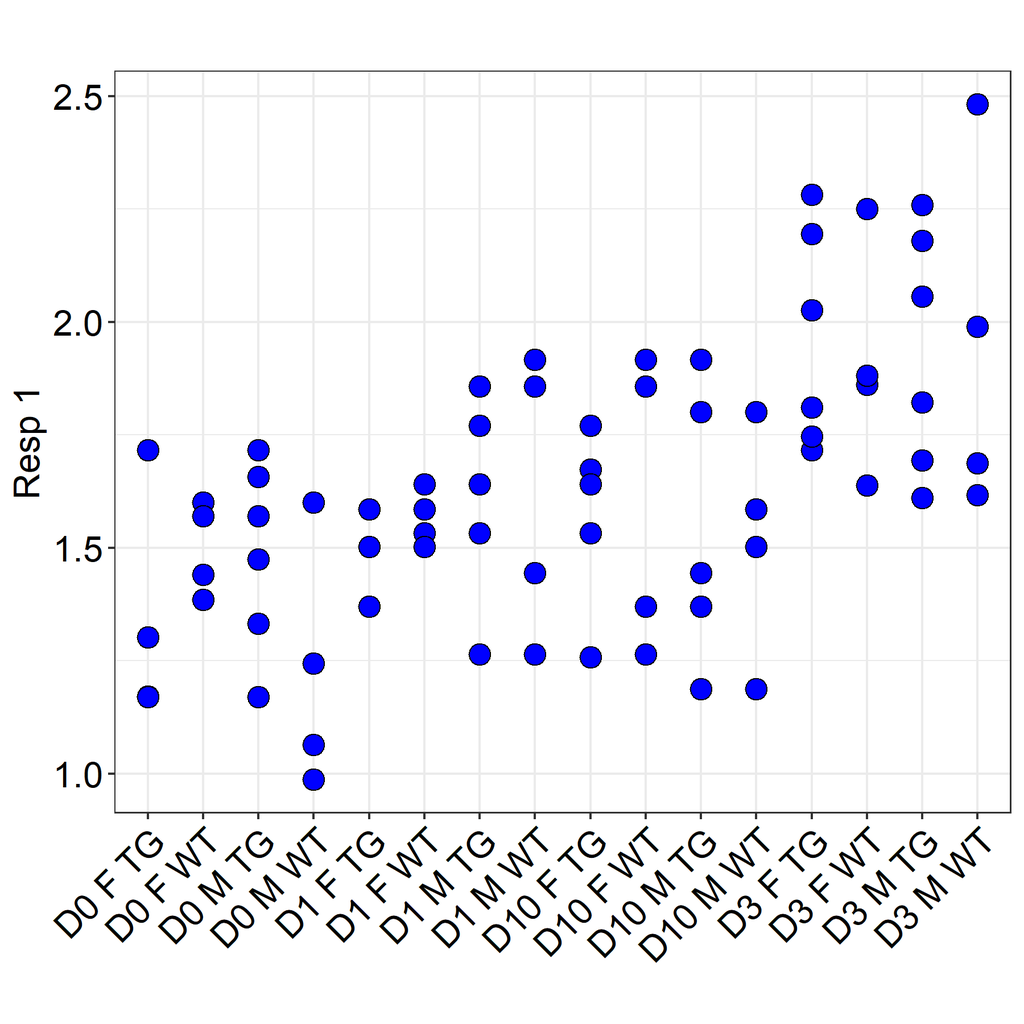

Tip: Use this plot to identify possible outliers.

## Analysis of variance (ANOVA) table

| Effect | Sums of squares | Degrees of freedom | Mean square | F-value | p-value |
| --- | --- | --- | --- | --- | --- |
| Treat1 | 3.002 | 3 | 1.001 | 16.89 | < 0.0001 |
| Treat2 | 0.001 | 1 | 0.001 | 0.01 | 0.9115 |
| Treat3 | 0.001 | 1 | 0.001 | 0.02 | 0.8988 |
| Treat1 * Treat2 | 0.126 | 3 | 0.042 | 0.71 | 0.5490 |
| Treat1 * Treat3 | 0.025 | 3 | 0.008 | 0.14 | 0.9354 |
| Treat2 * Treat3 | 0.069 | 1 | 0.069 | 1.16 | 0.2852 |
| Treat1 * Treat2 * Treat3 | 0.160 | 3 | 0.053 | 0.90 | 0.4469 |
| Residual | 3.674 | 62 | 0.059 |  |  |

Comment: ANOVA table calculated using a Type III model fit, see Armitage et al. (2001).

Conclusion: At the 10% level, there is a statistically significant overall difference between the levels of Treat1.

Tip: While it is a good idea to consider the overall tests in the ANOVA table, we should not rely on them when deciding whether or not to make pairwise comparisons.

## Model coefficients

|  | Estimate | Std. Error | t-value | p-value |
| --- | --- | --- | --- | --- |
| (Intercept) | 1.6138 | 0.0281 | 57.39 | < 0.0001 |
| Treat11 | -0.2262 | 0.0499 | -4.54 | < 0.0001 |
| Treat12 | -0.0450 | 0.0483 | -0.93 | 0.3548 |
| Treat13 | -0.0529 | 0.0483 | -1.09 | 0.2779 |
| Treat21 | 0.0031 | 0.0281 | 0.11 | 0.9115 |
| Treat31 | 0.0036 | 0.0281 | 0.13 | 0.8988 |
| Treat11:Treat21 | 0.0290 | 0.0499 | 0.58 | 0.5630 |
| Treat12:Treat21 | -0.0642 | 0.0483 | -1.33 | 0.1890 |
| Treat13:Treat21 | 0.0409 | 0.0483 | 0.85 | 0.4006 |
| Treat11:Treat31 | 0.0222 | 0.0499 | 0.45 | 0.6572 |
| Treat12:Treat31 | -0.0277 | 0.0483 | -0.57 | 0.5683 |
| Treat13:Treat31 | -0.0031 | 0.0483 | -0.06 | 0.9492 |
| Treat21:Treat31 | -0.0303 | 0.0281 | -1.08 | 0.2852 |
| Treat11:Treat21:Treat31 | -0.0753 | 0.0499 | -1.51 | 0.1361 |
| Treat12:Treat21:Treat31 | -0.0032 | 0.0483 | -0.07 | 0.9479 |
| Treat13:Treat21:Treat31 | 0.0328 | 0.0483 | 0.68 | 0.5001 |

## Diagnostic plots

### Residuals vs. predicted plot

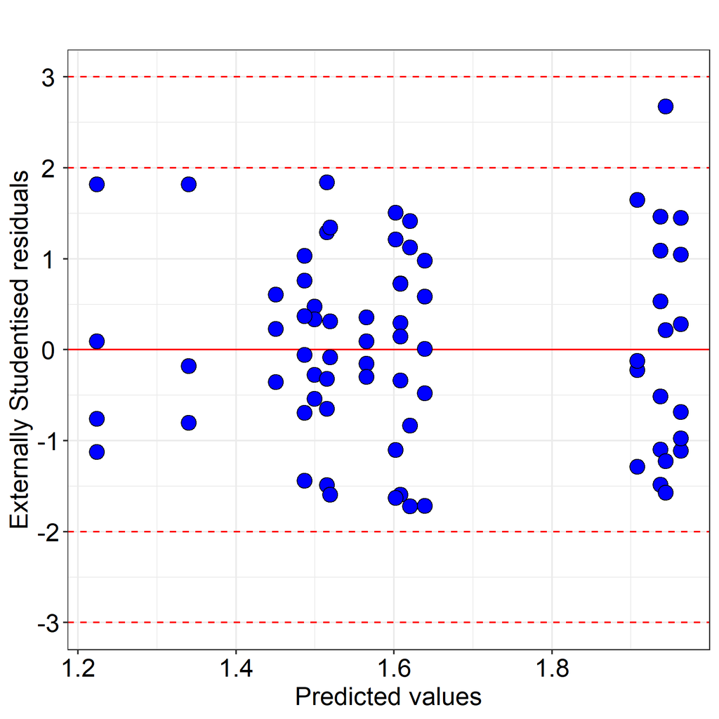

Tip: On this plot look to see if the spread of the points increases as the predicted values increase. If so the response may need transforming.

Tip: Any observation with a residual less than -3 or greater than 3 (SD) should be investigated as a possible outlier.

### Normal probability plot

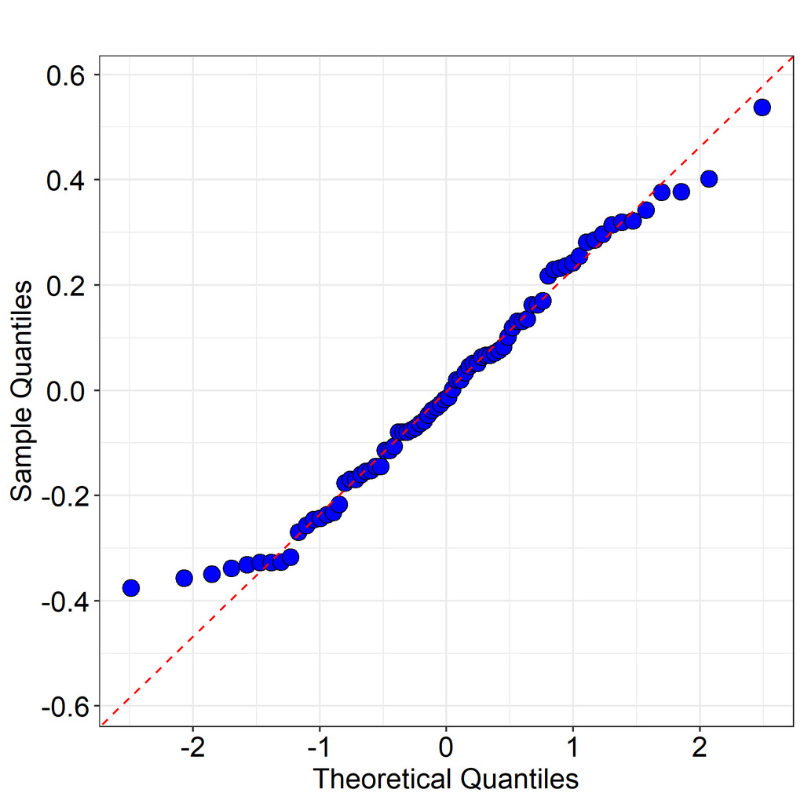

Tip: Check that the points lie along the dotted line. If not then the data may be non-normally distributed.

## Table of the least square (predicted) means with 90% confidence intervals

| Mean ID | Treat1 | Mean | Lower 90% CI | Upper 90% CI |
| --- | --- | --- | --- | --- |
| 1 | D0 | 1.388 | 1.290 | 1.485 |
| 2 | D1 | 1.569 | 1.476 | 1.661 |
| 3 | D10 | 1.561 | 1.468 | 1.654 |
| 4 | D3 | 1.938 | 1.845 | 2.031 |

## Plot of the least square (predicted) means with 90% confidence intervals

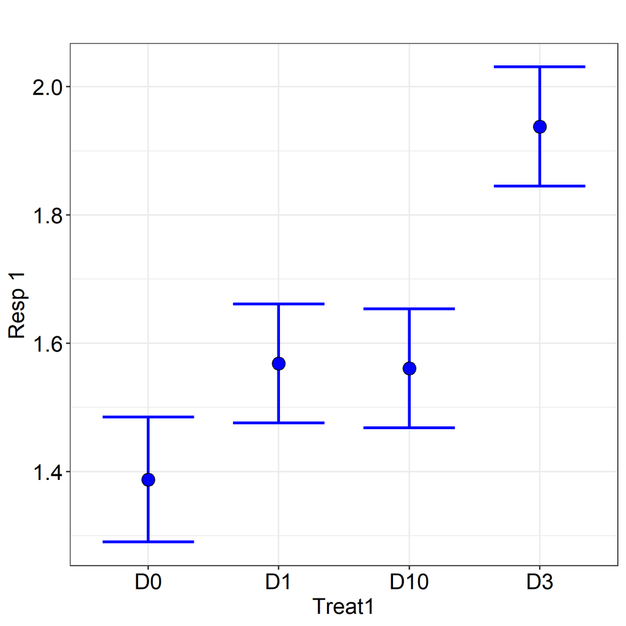

## All pairwise comparisons using Holm's procedure

| Comparison | Difference | Lower 90% CI | Upper 90% CI | Std error | p-value |
| --- | --- | --- | --- | --- | --- |
| D0 - D1 | -0.181 | -0.316 | -0.047 | 0.081 | 0.0838 |
| D0 - D10 | -0.173 | -0.308 | -0.039 | 0.081 | 0.0838 |
| D0 - D3 | -0.550 | -0.685 | -0.416 | 0.081 | < 0.0001 |
| D1 - D10 | 0.008 | -0.123 | 0.139 | 0.079 | 0.9208 |
| D1 - D3 | -0.369 | -0.500 | -0.238 | 0.079 | < 0.0001 |
| D10 - D3 | -0.377 | -0.508 | -0.246 | 0.079 | < 0.0001 |

Conclusion: The following pairwise comparisons are statistically significant at the 10% level: (1) D0 - D1, (2) D0 - D10, (3) D0 - D3, (4) D1 - D3, (5) D10 - D3.

Warning: It is not advisable to draw statistical inferences about a factor/interaction in the presence of a significant higher-order interaction involving that factor/interaction.

Warning: This procedure makes an adjustment assuming you want to make all pairwise comparisons. If this is not the case then these tests may be unduly conservative. You may wish to use planned comparisons (using unadjusted p-values) instead, see Snedecor and Cochran (1989), or make a manual adjustment to the unadjusted p-values using the InVivoStat P-value Adjustment module.

Note: The confidence intervals quoted are not adjusted for multiplicity.

## All to one comparisons using Holm's procedure

| Comparison | Difference | Lower 90% CI | Upper 90% CI | Std error | p-value |
| --- | --- | --- | --- | --- | --- |
| D1 - D0 | 0.181 | 0.047 | 0.316 | 0.081 | 0.0559 |
| D10 - D0 | 0.173 | 0.039 | 0.308 | 0.081 | 0.0559 |
| D3 - D0 | 0.550 | 0.416 | 0.685 | 0.081 | < 0.0001 |

## Plot of the comparisons between the predicted means with 90% confidence intervals

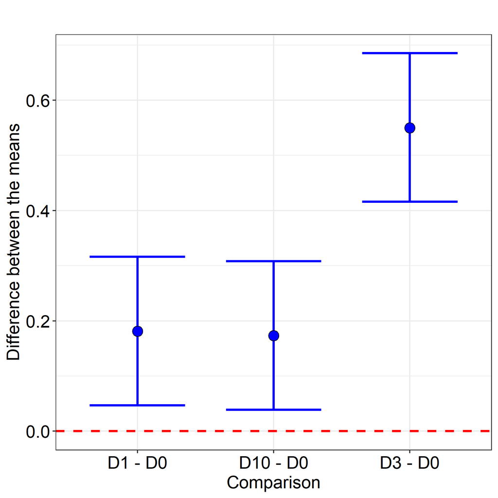

Conclusion: The following pairwise comparisons are statistically significant at the 10% level: (1) D1 - D0, (2) D10 - D0, (3) D3 - D0.

Warning: It is not advisable to draw statistical inferences about a factor/interaction in the presence of a significant higher-order interaction involving that factor/interaction. In the above table certain higher order interactions are assumed to be not significant, see log for more details.

Note: The confidence intervals quoted are not adjusted for multiplicity.

## Analysis description

The data were analysed using a 3-way ANOVA approach, with Treat1, Treat2 and Treat3 as the treatment factors. This was followed by comparisons of the predicted means of the Treat1 factor back to the control group mean using Holm's procedure, Holm (1979). This was followed by all pairwise comparisons between the predicted means of the Treat1 factor using Holm's procedure, Holm (1979).

For more information on the theoretical approaches that are implemented within this module, see Bate and Clark (2014).

## References

When referring to InVivoStat, please cite 'InVivoStat, version 5.2.0'.

Bate, S.T. and Clark, R.A. (2014). The Design and Statistical Analysis of Animal Experiments. Cambridge University Press.

Armitage, P., Matthews, J.N.S. and Berry, G. (2001). Statistical Methods in Medical Research. 4th edition; John Wiley & Sons. New York.

Holm, S. (1979). A simple sequentially rejective multiple test procedure. Scandinavian Journal of Statistics, 6, 65-70.

Snedecor, G.W. and Cochran, W.G. (1989). Statistical Methods. 8th edition; Iowa State University Press, Iowa, USA.